# Cecilia’s Portfolio 2025

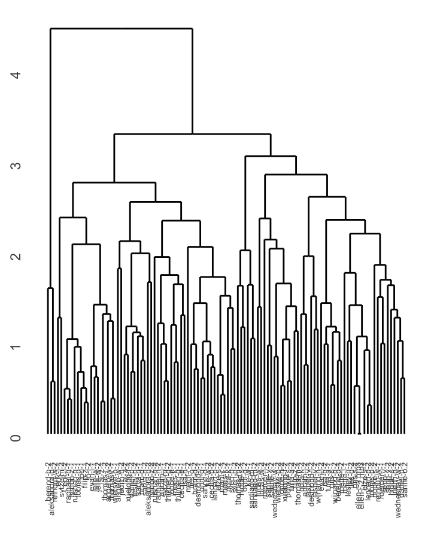

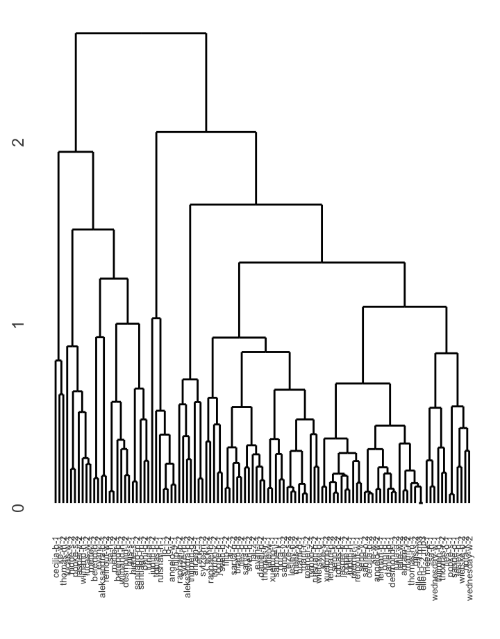

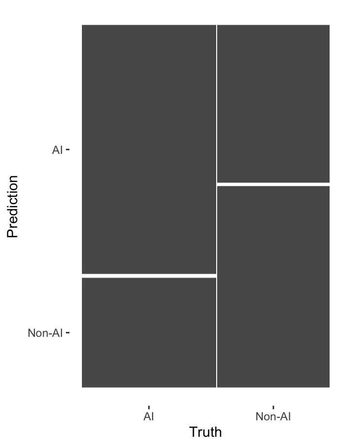

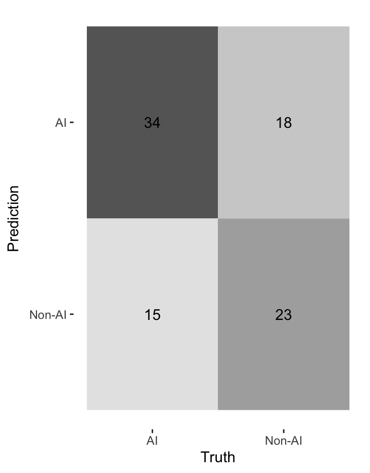

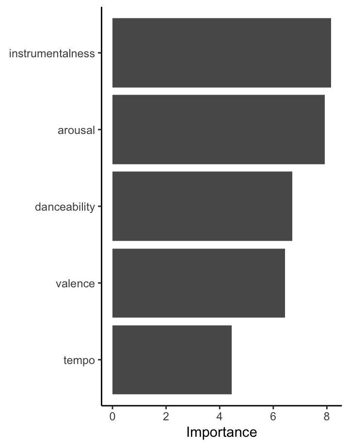

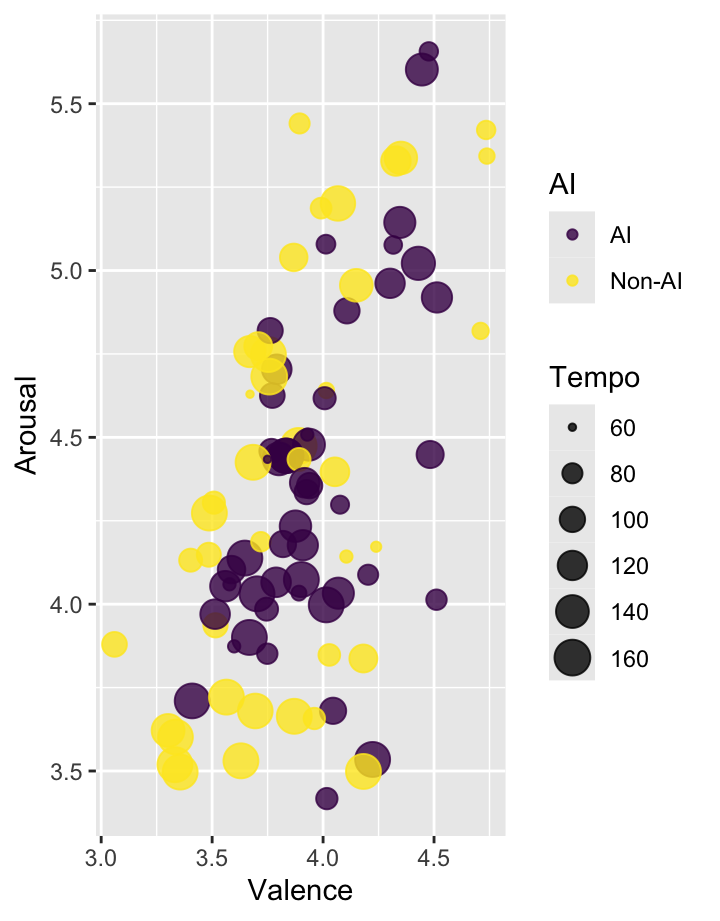

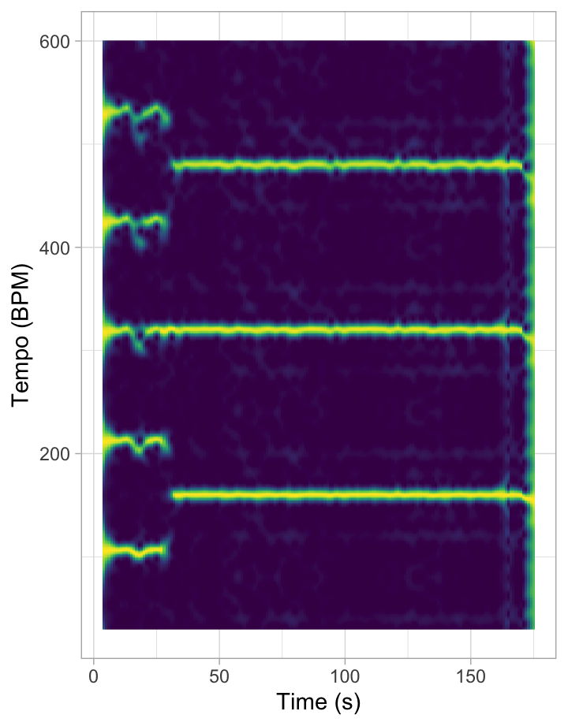

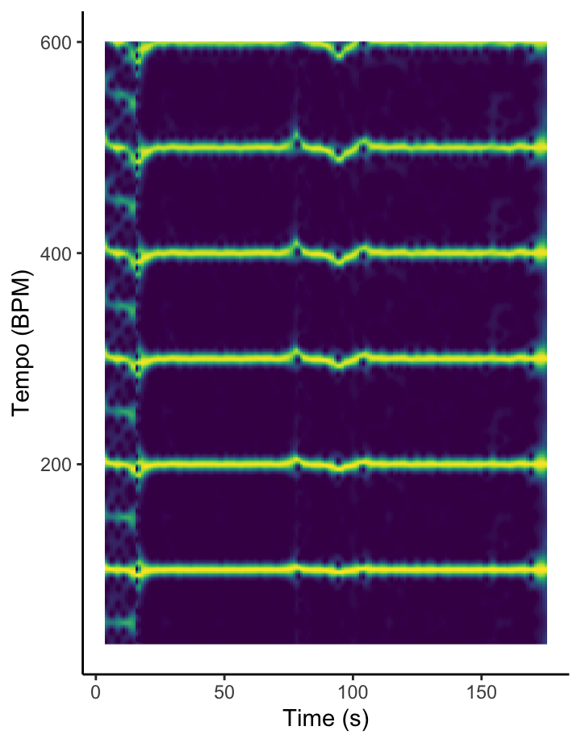

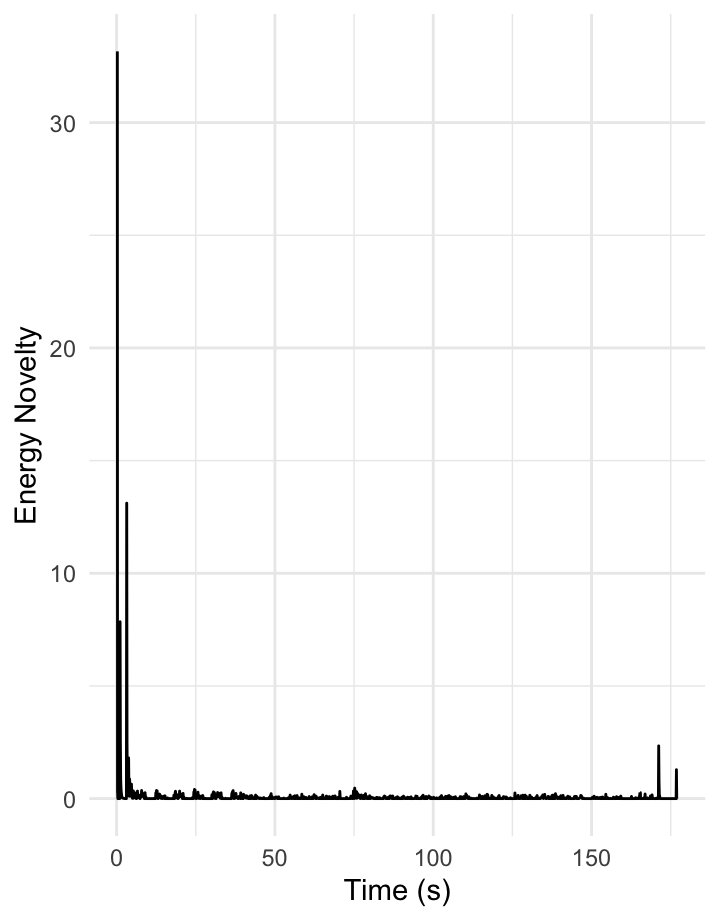

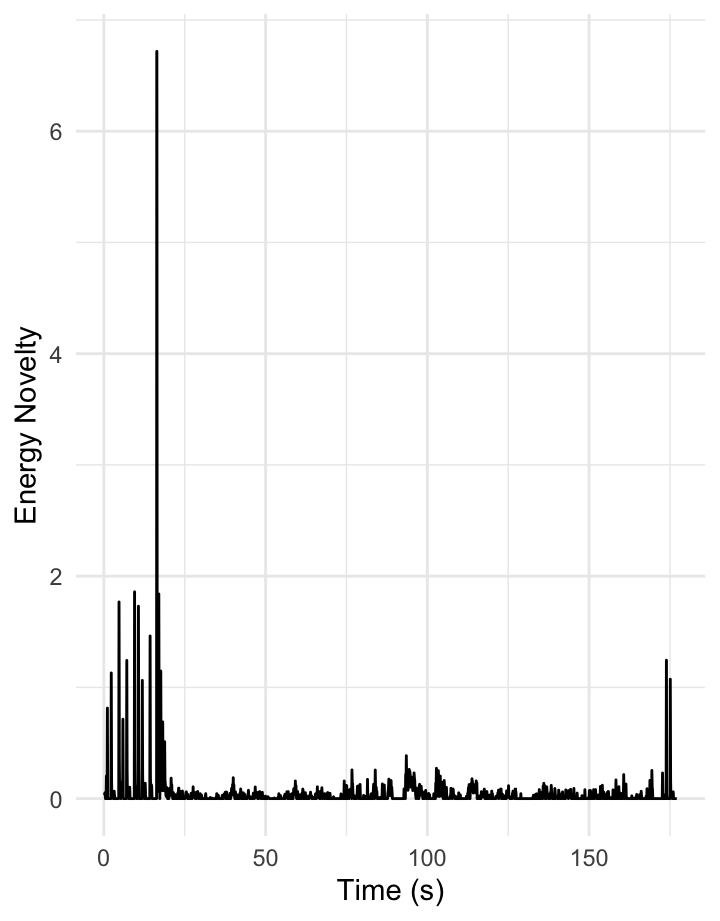

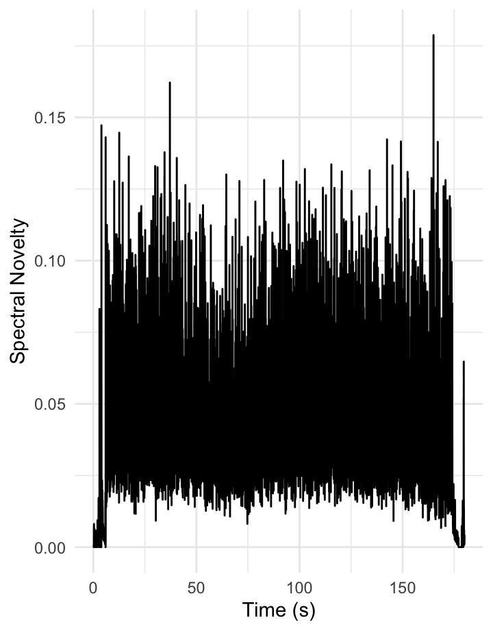

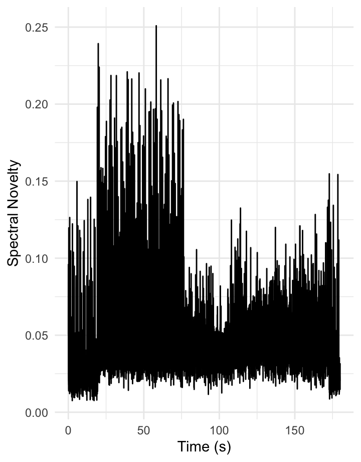

[10 more figures not shown]

## Computational Musicology Portfolio 2025

Welcome :)

### Comparing dendrograms of class corpus week 12

#### Dendrogram with all features

So for this assignment I decided to compare two dendrograms of the class corpus. The first one is with all the features (arousal, danceability, instrumentalness, tempo and valence), as for the second only has arousal and valence. My prediction is that if you get rid of some of the features, the song will become less different. Lets find out!

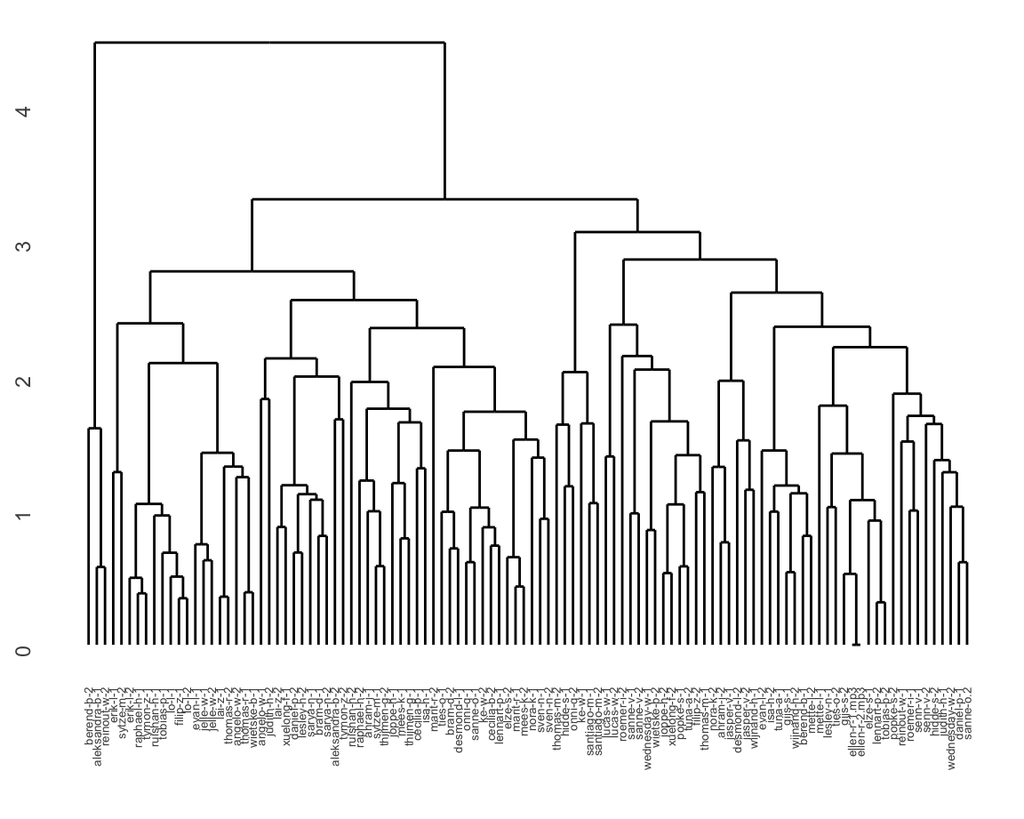

#### Dendrogram with only arousal and valence

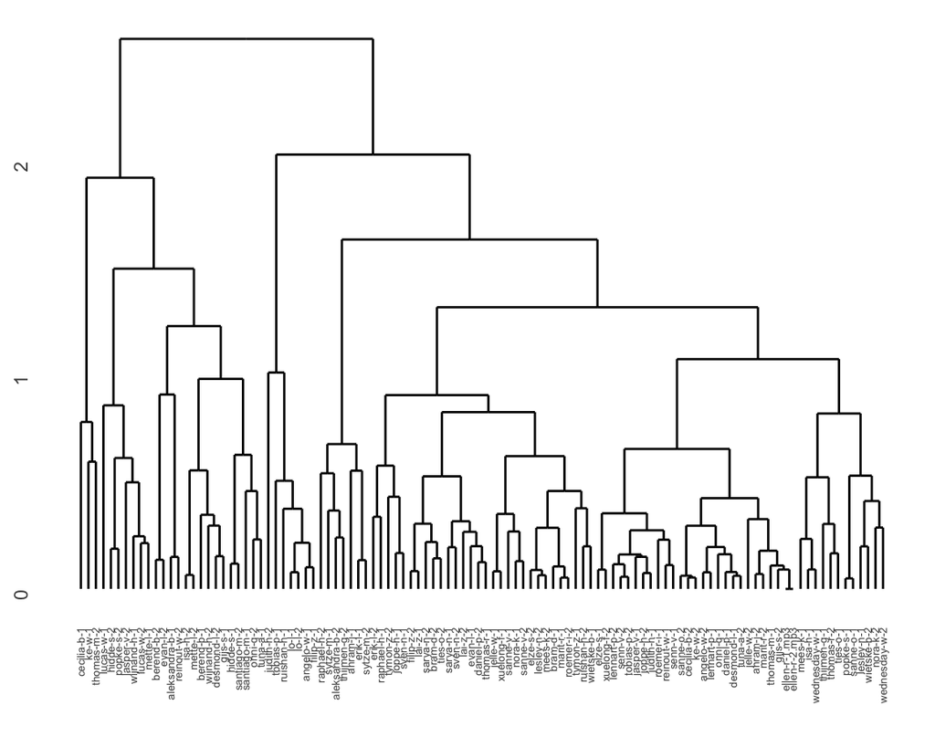

As you can see, the dendrograms look different. In the first one, the y-axis counts till 4 (and even over 4), as in the second one it doesn’t get much higher than two. The tracks are still all very different compared to eachother, but my hypothesis was right that they are a bit more similar compared to if you use all the features

### AI or non AI?

#### Prediction

Here we’re going to look at the prediction. Does the computer think the tracks are AI or non AI?

```
          Truth
Prediction AI Non-AI
    AI     34     18
    Non-AI 15     23
```

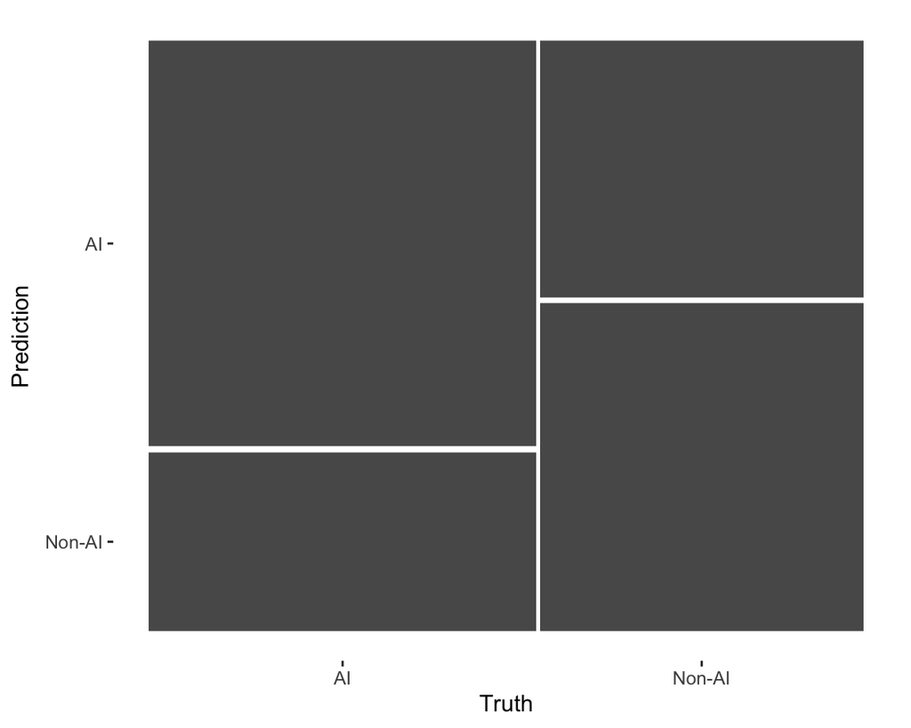

This shows how well AI-generated and human-created music based on their characteristics.

Ik we break it down: - Top-left block: AI predicted as AI - Bottom-right block: Non-AI predicted as non-AI - Top-right block: Non-AI incorrectly predicted as AI - Bottom-left block: AI incorrectly as Non-AI

As you can see, the classification was mostly accurate, because the top-left and right-bottom are the biggest blocks, but there were also some songs classified incorrectly.

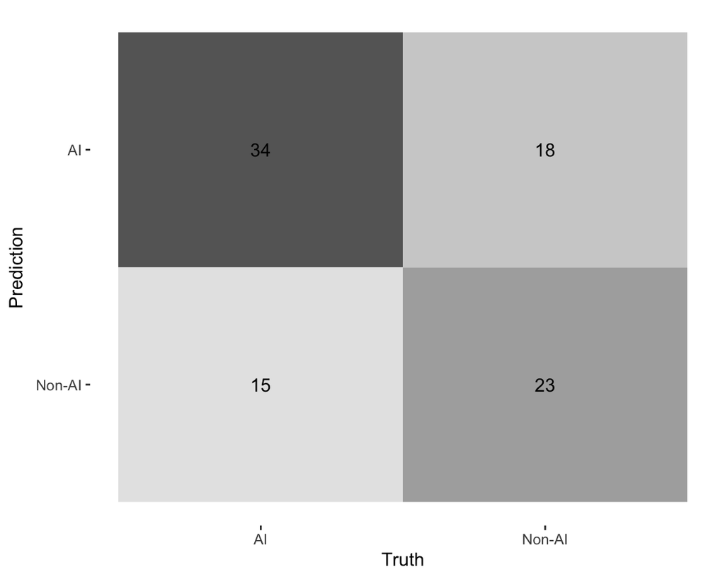

#### Forest-model

[output not shown]

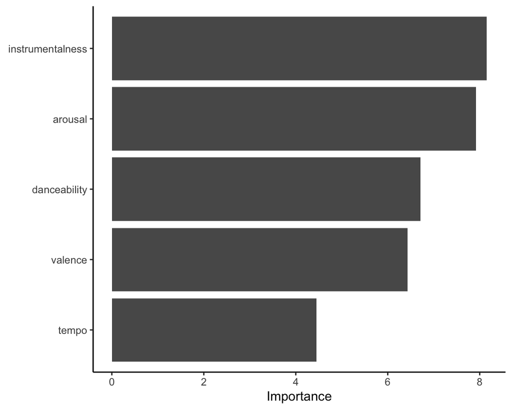

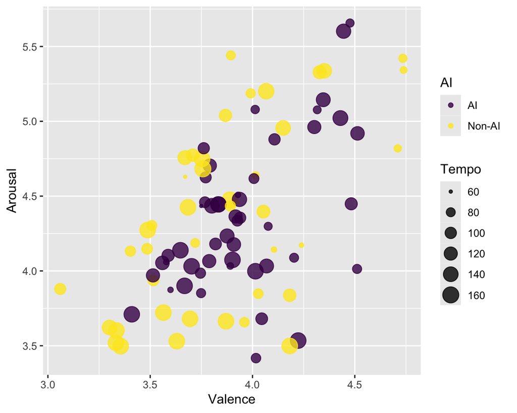

This graph is based on our class corpus. Each dot represents a song, purple = AI, yellow = non AI. The size of the dots are BPM.

### Tempograms week 11

#### Tempogram Track 1

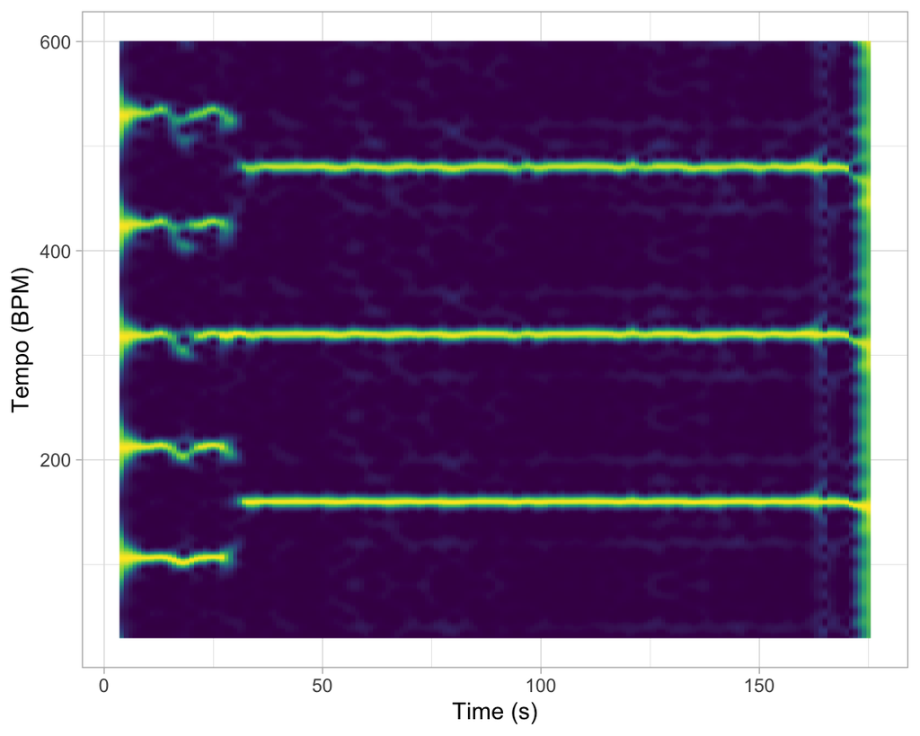

#### Tempogram Track 2

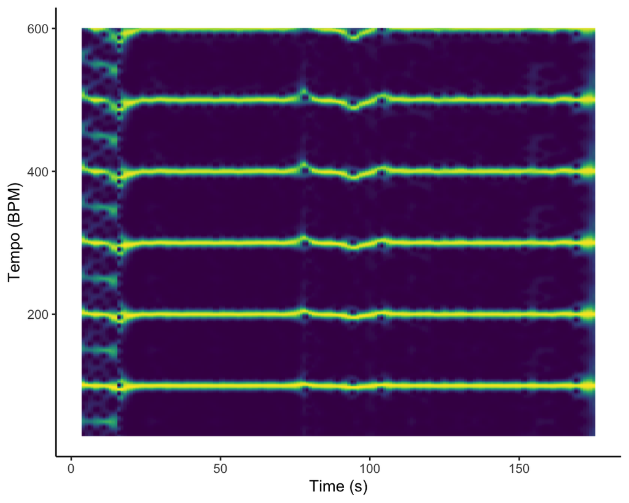

### Novelty Function: Energy

#### Energy Novelty Track 1

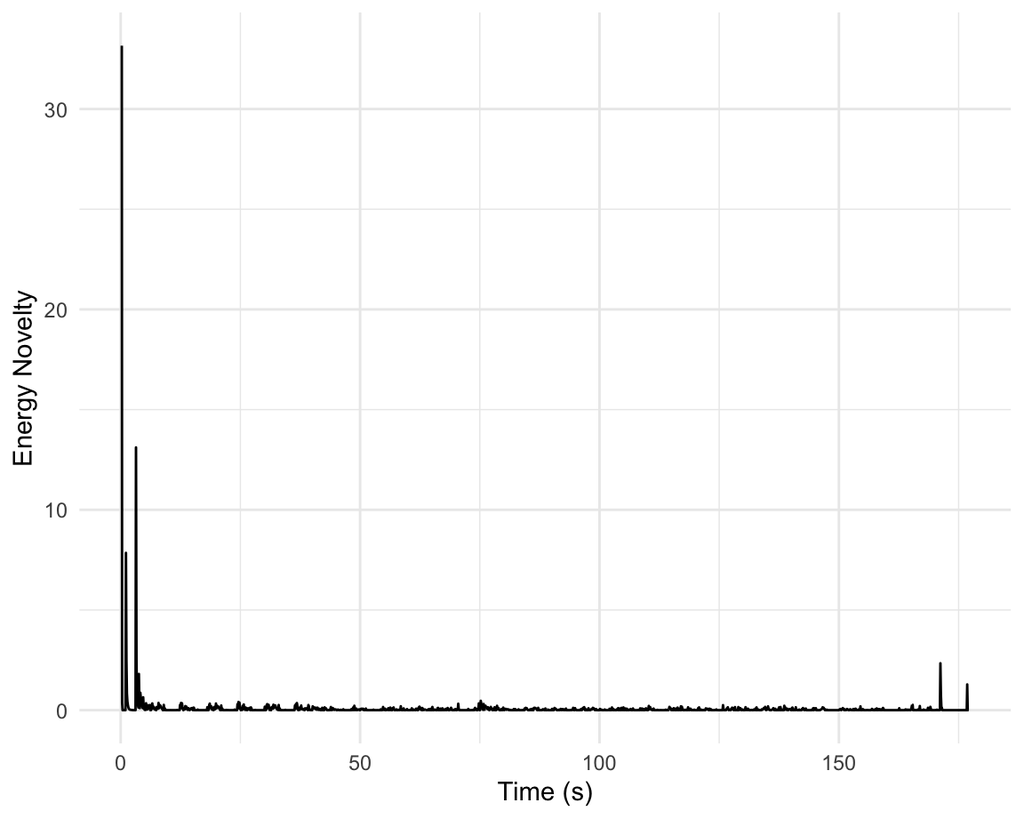

As you can see, this track doesn’t have a lot of energy whatsoever. This track contains chill, relaxing ukulele music so ‘low energy’ was also my goal. It is kind of boring and as you can see, there’s no energy to be found!

#### Energy Novelty Track 2

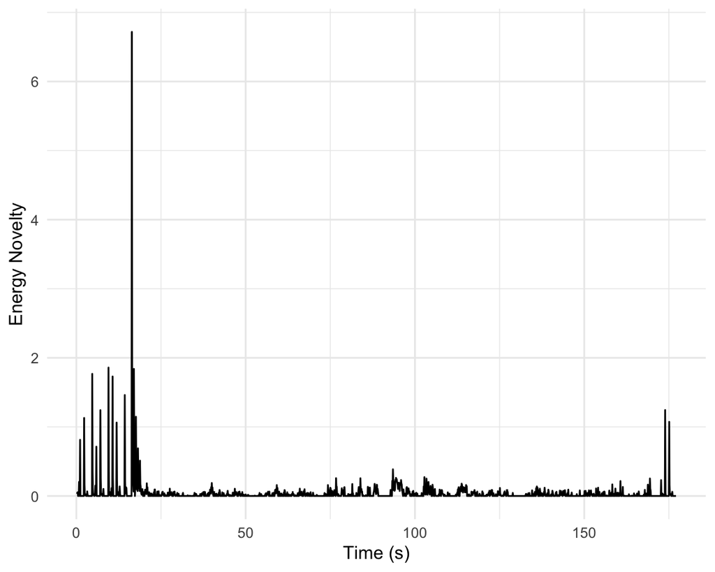

My second track is a bit more energetic compared to my first one, but less than I imagined. You can clearly see the ‘beat-drop’ 20 seconds into the track, but afterwards there is also hardly any energy in this track

### Novelty function: spectral

#### Spectral Novelty Track 1

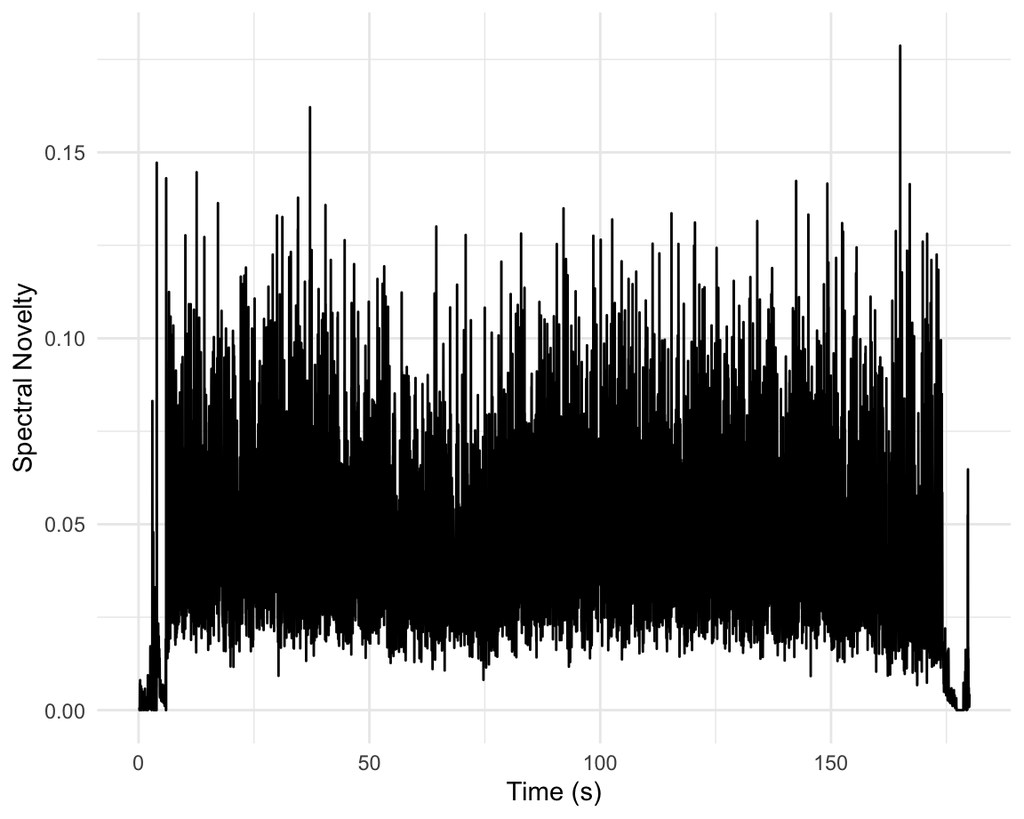

If you look at this graph of my first track, you can see that it’s almost completely the same during the whole song.

#### Spectral Novelty Track 2

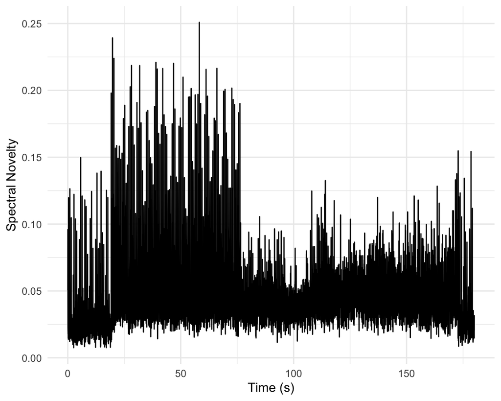

### Chordogram week 10

#### Chordogram Track 1

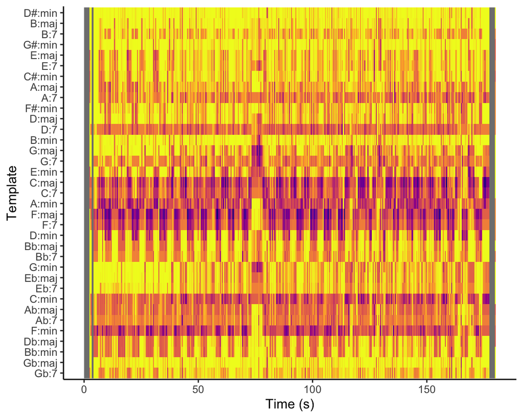

In this chordogram, you can see that specific chords were played throughout the entire song. F- and C major are the most obvious ones. This track also contains a ukulele playing the chords, so the chordogram looks pretty logic to me.

#### Chordogram Track 2

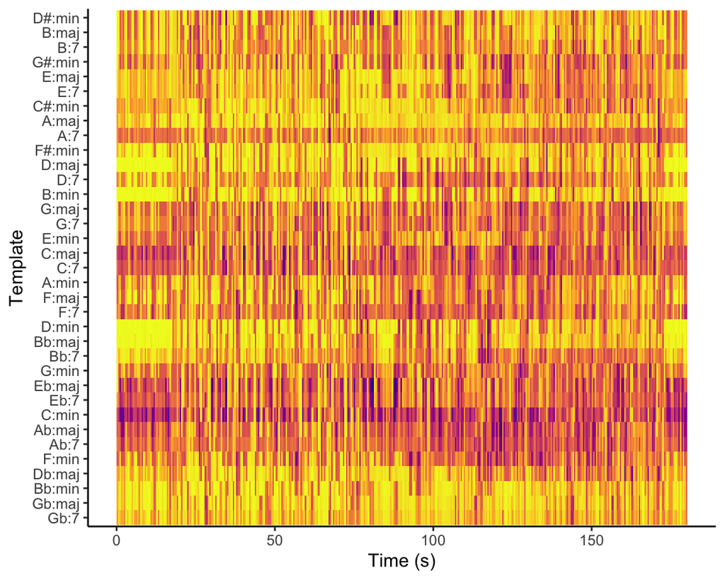

So if you compare this chordogram to the first one, you can see that there are less chords. The colors aren’t as clear and not as long as the blocks in track 1. When listening to the track this makes sense, because I can’t really hear many chords whatsoever.

Oh and if you read this and know how I can put my texts next to the graphs in stead of under them: please send me a message or add it to the comments! Very much appreciated :)

### Chromagram Analysis

#### Chromagram Track 1

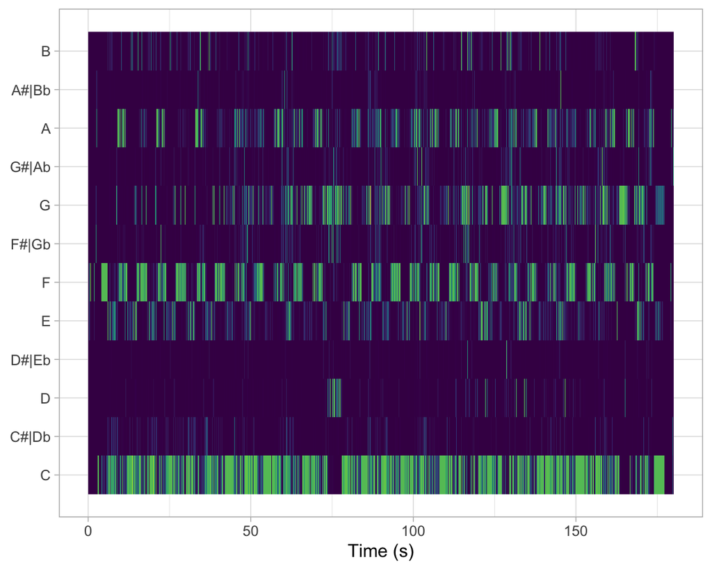

Figure: Chromagram of Cecilia B-1

This chromagram visualizes the pitch class distribution over time for my first track. The x-axis represents time in seconds, while the y-axis corresponds to the 12 pitch classes (C to B), including enharmonic equivalents (e.g., C#|Db). The color intensity indicates the strength of each pitch class at a given moment, with brighter areas representing stronger presence. This visualization helps analyze harmonic content, tonality, and key changes throughout the track.

(I still want to analyze it further but ran out of time for now)

#### Chromagram Track 2

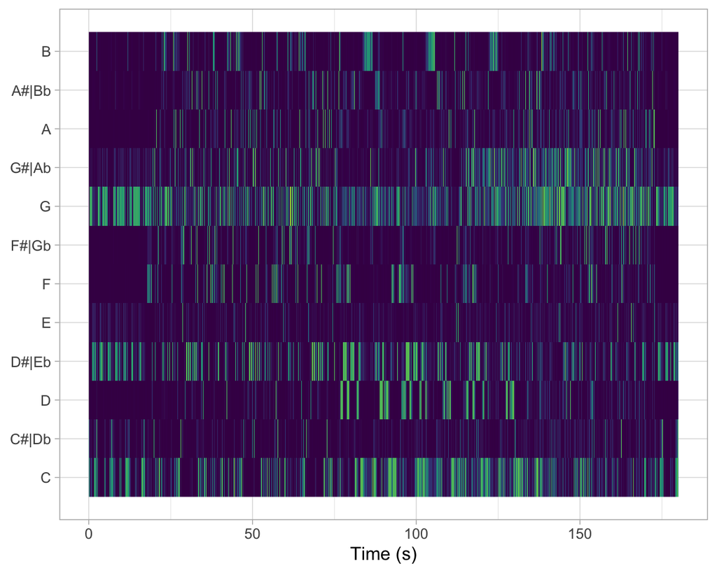

Figure: Chromagram of Cecilia B-2

This chromagram represents the pitch class distribution over time for my second track. The x-axis shows time in seconds, while the y-axis corresponds to the 12 pitch classes (C to B), including enharmonic equivalents.

(I still want to analyze it further, and compare both chromagrams but ran out of time for now)

### Cepstrogram Analysis

#### Cepstrogram Track 1

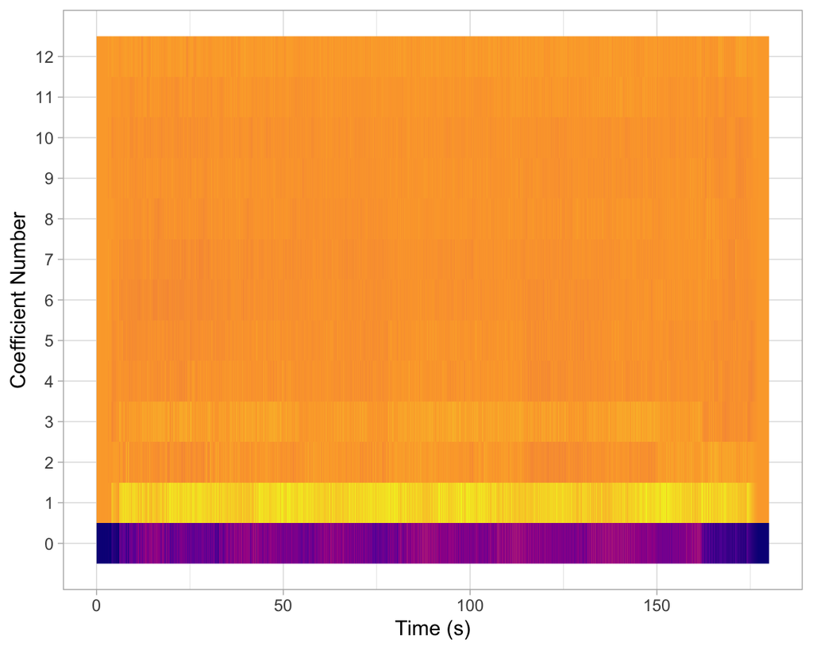

Figure: Cepstrogram of Cecilia B-1

This cepstrogram visualizes the evolution of Mel-Frequency Cepstral Coefficients (MFCCs) over time for my first track. The x-axis represents time in seconds, while the y-axis indicates the MFCC coefficient number, which captures different aspects of the spectral envelope. The color intensity (using the plasma color scale) shows the strength of each coefficient at a given moment, with brighter colors representing higher magnitudes. MFCCs are commonly used for timbre analysis, making this plot useful for understanding tonal quality, texture, and distinguishing different sound characteristics within the track.

#### Cepstrogram Track 2

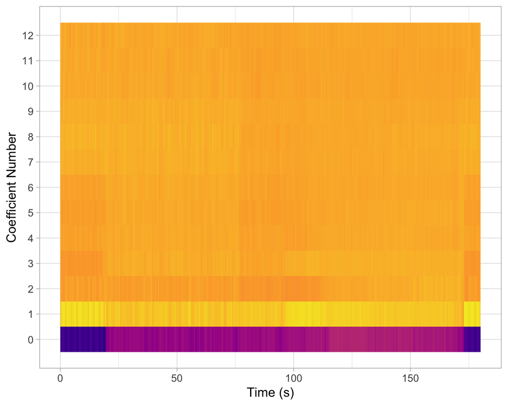

Figure: Cepstrogram of Cecilia B-2

This cepstrogram displays the progression of Mel-Frequency Cepstral Coefficients (MFCCs) over time for my second track.

(I still want to analyze it further, and compare both cepstrograms but ran out of time for now)

### Self-similarity Matrices Track 1

#### Chroma-based self-similarity matrix track 1

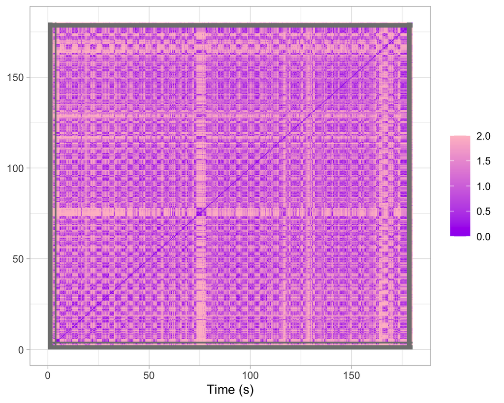

This visualization helps analyze harmonic consistency and motif recurrence within the track.

#### Timbre-based self-similarity matrix track 1

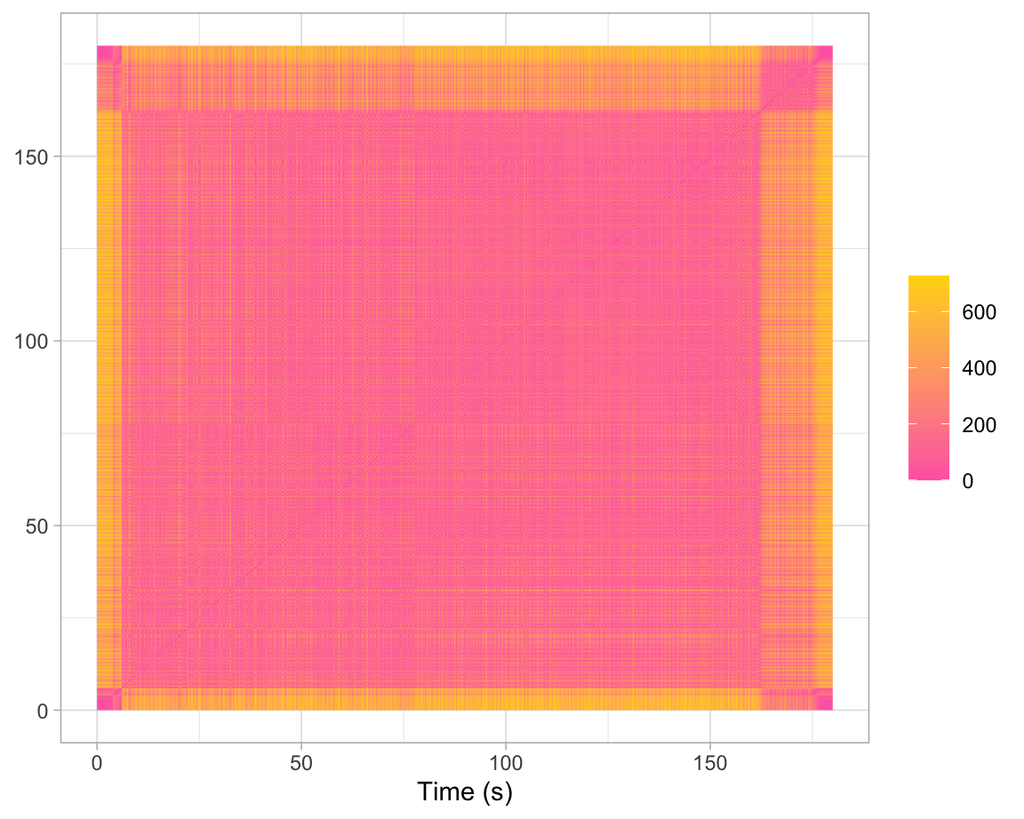